# Topic Classification

[figure not shown]

# Overview

My work consist of both classification and clustering analysis.

**Clustering**:  
I used two different approaches.

- In the first one, I used **Latent Dirichlet Allocation** method and worked with the tf-idf scheme. I detected several (per-class) topics by considering the most powerful words.
- In the second one, I constructed a Word Network upon which I applied **Community Detection** using the **Louvain** method. The detected communities express different topics. Also, I extracted features in order to improve my models performance regarding the classification task.

**Classification**:  
I used two different representations, **Td-idf** and **Word Embeddings**.

- In the first case I used several sklearn classifiers
- In the second I implemented an LSTM in pytorch  
  (In both cases I didn't tune the hyper-paremeters)

# Import Modules and Prerequisites

```python
# general
import pandas as pd
import numpy as np
import matplotlib.pyplot as plt
import re
import itertools
from my_functions import print_topics, plot_10_most_common_words, plot_confusion_matrix, evaluate_classifiers, grid_tuning, voting3, elbow_method_kmeans
from mpl_toolkits.mplot3d import Axes3D
import pickle


# text analysis
from sklearn.feature_extraction.text import TfidfVectorizer
from sklearn.feature_extraction.text import CountVectorizer
from greek_stemmer import GreekStemmer
from greek_accentuation.characters import *
import spacy
from spacy.lang.el.stop_words import STOP_WORDS
from wordcloud import WordCloud
#from bert_embedding import BertEmbedding

# preprocessing
from sklearn.decomposition import PCA
from sklearn.preprocessing import StandardScaler
from sklearn.preprocessing import MinMaxScaler
from sklearn.model_selection import train_test_split
from sklearn.model_selection import cross_val_score
from sklearn.metrics import accuracy_score
from sklearn.model_selection import KFold
from sklearn.metrics import confusion_matrix
from sklearn.metrics import classification_report

# classification
from sklearn.linear_model import LogisticRegression
from sklearn.svm import SVC
from sklearn.neighbors import KNeighborsClassifier
from sklearn.naive_bayes import GaussianNB
from lightgbm import LGBMClassifier
from xgboost import XGBClassifier
from sklearn.ensemble import AdaBoostClassifier
from sklearn.ensemble import VotingClassifier
from sklearn.ensemble import BaggingClassifier

# clustering
from sklearn.decomposition import LatentDirichletAllocation
from sklearn.cluster import KMeans
import networkx as nx
import community

# pytorch
import torch
from torch import nn
import torch.nn.functional as F
from torch.utils.data import Dataset, DataLoader


data_path= 'data/'
images_path= 'images/'
pickles_path= 'pickles/'
```

# Import dataset

```python
#read the dataset
df = pd.read_csv(data_path+'data.csv')
df.head()
```

|  | text | label |
| --- | --- | --- |
| 0 | [Χάκερ, εγκατέστησαν, αποστάσεως, λογισμικό, κ... | 1 |
| 1 | [δυνατότητες, θαλάσσιου, τουρισμού, αναπτυχθεί... | 1 |
| 2 | [Άνδρες, συριακών, δυνάμεων, ασφαλείας, σκότωσ... | 0 |
| 3 | [υποστήριξή, πρώην, υπουργό, Εξωτερικών, Τζόνσ... | 1 |
| 4 | [σταθερή, προσήλωση, ΗΠΑ, Ελλάδας, εμβάθυνση, ... | 1 |

```python
#create the corpus
corpus= df['text'].values
y= df['label'].values
```

## Data understanding

### Classes Distribution

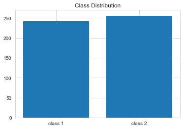

```python
vals, cnts= np.unique(y, return_counts=True)
plt.bar(vals,cnts)
plt.xticks(np.arange(len(vals)),['class '+  str(val+1) for val in vals])
plt.title('Class Distribution');
```

the dataset is almost balanced!

### Most Frequent Words

I found the per-class most frequent words, having already applied the pre-processing steps that you will see bellow.  
Here I present several words that does not express meaningful information.  
Thus, I manually removed them from every document.

Note that

- I used a dictionary in order to check if a random word belongs to this set of words in Θ(1) time complexity
- Using his step, the results weren't always get better. In some cases a small drop occured.

```python
my_stop_words={
    'σύμφωνα':1,
    'πηγή':1,
    'σήμερα':1,
    'δήλωσε':1,
    'είπε':1,
    'ανέφερε':1,
    'αναφέρει':1,
    'τόνισε':1,
    'κάνει':1,
    'κι':1,
    'αναμένεται':1,
    'σημειώθηκε':1,
    'γίνει':1,
    'σήμερα':1,
    'χθες':1,
    'δει':1,
    'gr':1,
    'διότι':1,
    'περιοχή':1,
    'περιοχές':1
}
```

### Classes Exploration

```python
tone_dict = {'Ά': 'Α',
             'Έ': 'Ε',
             'Ύ': 'Υ',
             'Ί': 'Ι',
             'Ό': 'Ο',
             'Ή': 'Η',
             'Ώ': 'Ω'}

stemmer = GreekStemmer()


def display_wordCloud(label):
    #extract the tokens
    class_tokens= [ token for doc in corpus[y==label] for token in  no_stem_tokenizer(my_preprocessor(doc)) ]
    #create the word cloud
    wc= WordCloud(max_words=100, width=2000,height=600).generate(' '.join(class_tokens))
    #print the word cloud
    plt.figure(figsize=(15,5))
    plt.imshow(wc)
    plt.title('Word Cloud of class {}'.format(label+1))

'''
arguments:
    doc: raw document as string
return:
    string containing the preprocessed words
'''

def my_preprocessor(doc):
    #convert the text to lower-case
    doc= doc.lower()
    #afairesi punctuation (may result in consecutive spaces)
    udoc = re.sub(r"[\W_]", ' ',doc)
    #convert consecutive spaces into one
    udoc = re.sub(r"\s+", ' ',udoc)
    #remove spaces from both the beginning and the end
    udoc= udoc.strip()
    return udoc


'''
arguments:
    doc: preprocessed document as string
return:
    list of tokens (strings)
'''

def my_tokenizer(doc):
    #tokenize
    words= doc.split()
    #remove stopwords
    filtered_words = [word for word in words if word not in STOP_WORDS]
    #remove article-specific stopwords
    filtered_words = [word for word in filtered_words if word not in my_stop_words ]
    #remove words with length == 1 (these words are: 'o','ή','α','β','γ','ε',','κ','ν','π','σ','χ','ό')
    filtered_words = [word.upper() for word in filtered_words if len(word) > 1]
    #stemming
    no_tone_words = []
    for word in filtered_words:
        no_tone_word = []
        for char in word:
            if char in tone_dict.keys():
                char = tone_dict[char]
            no_tone_word.extend(char)
        no_tone_word = ''.join(no_tone_word).upper()
        no_tone_words.append(no_tone_word)
    filtered_words = [stemmer.stem(word).lower() for word in no_tone_words]
    filtered_words = [word for word in filtered_words if len(word) > 1]
    return filtered_words

def no_stem_tokenizer(doc):
    #tokenize
    words= doc.split()
    #remove stopwords
    filtered_words = [word for word in words if word not in STOP_WORDS]
    #remove article-specific stopwords
    filtered_words = [word for word in filtered_words if word not in my_stop_words ]
    #remove words with length == 1 (these words are: 'o','ή','α','β','γ','ε',','κ','ν','π','σ','χ','ό')
    filtered_words = [word for word in filtered_words if len(word) > 1]
    return filtered_words
```

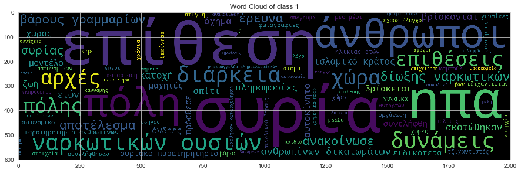

```python
display_wordCloud(0)
```

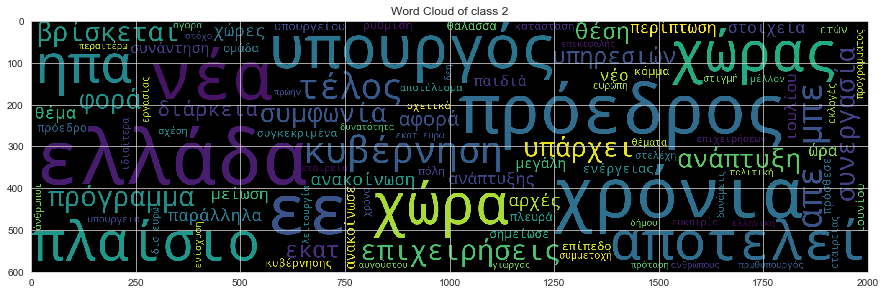

```python
display_wordCloud(1)
```

**This is the first, naive way of understanding the nature of each class**:

- **Class 1** consist of articles regarding news from arround the world.  
  In addition, these news seems to be about war/attacks, drugs and human rights.
- **Class 2** consist of articles regarding news from Greece.  
  In addition, this category seems to be about Politics and Government News.

#### However, the Clustering section will provide us with clear insights

### Documents length

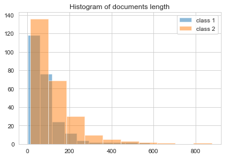

```python
for label in [0,1]:
    class_lengths= [ len( my_tokenizer(my_preprocessor(doc))) for doc in corpus[y==label] ]
    plt.hist(class_lengths, bins=10,alpha=0.5, label='class '+str(label+1))
    plt.title('Histogram of documents length'.format(label+1));
plt.legend();
```

Class 2 consists of larger documents

# Topic Extraction

## Latent Dirichlet Allocation

```python
vectorizer_count = CountVectorizer(preprocessor=my_preprocessor, tokenizer=my_tokenizer, min_df=5)
corpus_count = vectorizer_count.fit_transform(corpus)
```

In this part we consider all the documents together ignoring their labels

```python
number_topics = 4
number_words = 10

lda = LatentDirichletAllocation(n_components=number_topics)
lda.fit(corpus_count)

#print the topics
print_topics(lda, vectorizer_count, number_words)
```

```
Topic #1:
χωρ νε ελλην χρον ελλαδ μεγαλ αναπτυξ φωτογραφ εταιρει φορ

Topic #2:
επιθες χωρ προεδρ συρι δυναμ πολ ανθρωπ αμερικαν κρατ τουρκ

Topic #3:
αστυνομ ναρκωτ οδηγ ευρ βαρ αυτοκινητ ελεγχ συνολ ερευν τμημ

Topic #4:
νε ρυθμις προγραμμ υπηρες πολιτ οφειλ κεντρ κοινων νομ επιχειρης
```

### LDA - Class 1, 2

```python
number_topics = [4,3]
number_words = 10
vect, data, name= [vectorizer_count,corpus_count,"Count Vectorizer"]
print("Bag of words representation:", name)
print("===============================================================================")
for label in [0,1]:
    print('............ Topics of class #{} ............\n'.format(label+1))
    lda = LatentDirichletAllocation(n_components=number_topics[label])
    lda.fit(data[y==label])
    #print the topics
    print_topics(lda, vect, number_words)
print("\n")
```

```
Bag of words representation: Count Vectorizer
===============================================================================
............ Topics of class #1 ............

Topic #1:
αστυνομ ναρκωτ οδηγ βαρ αυτοκινητ ερευν γραμμαρ τμημ κανναβ οχημ

Topic #2:
φωτογραφ φορ μοντελ σεξ χωρ χρον νε επιθες καλλον γνωστ

Topic #3:
συρι συριακ ανταρτ ανθρωπ σκοτωθ δυναμ τουρκ ρως πολ παρατηρητηρ

Topic #4:
επιθες ισλαμ αμερικαν χωρ κρατ τζιχαντιστ δυναμ στρατιωτ οργανως πολ

............ Topics of class #2 ............

Topic #1:
χωρ προεδρ ελλαδ υπουργ νε μεγαλ δυναμ ελλην οικονομ πολιτ

Topic #2:
νε εκλογ κομμ κυβερνης πολιτ υπουργ μεγαλ προεδρ ρυθμις πολ

Topic #3:
ευρ χρον νε χωρ προγραμμ ελλην εκατ υπηρες δημιουργ παιδ
```

# Clustering

```python
vectorizer_tf_idf = TfidfVectorizer(preprocessor=my_preprocessor, tokenizer=no_stem_tokenizer, min_df=5)
corpus_tf_idf = vectorizer_tf_idf.fit_transform(corpus)
```

In this section we will try to better interpret and validate the fuzzy results of LDA by using clustering algorithms and visualisations based on 2D and 3D projections using PCA.

## PCA

We create PCA version of X to be used for 2D and 3D visualisations.

```python
# PCA for plotting
pc_num= 3
pca = PCA(n_components=3)
pca.fit(corpus_tf_idf.toarray())
X_pca = pca.transform(corpus_tf_idf.toarray())
print(pca.explained_variance_ratio_)
```

```
[0.02044724 0.01449916 0.01363502]
```

It is important to mention that the explained variance of the 3 first principal components is very small (around 5%) so we do not expect good results in terms of visualisations.

## GMM clustering and DBscan

GMM clustering and the DBscan algorithm were considered but were rejected because k-means would did the job better and in much more efficient manner.

## K-means clustering

### Whole dataset

We split to 2 clusters in order to check if these clusters could possibly agree with the classification labels

```python
def PCA_plots(X_3d, labels, title='Kmeans'):
    #2D
    plt.figure()
    ax1 = plt.axes()
    for g in np.unique(labels):
        ix = np.where(labels == g)
        xs = X_3d[ix, 0]
        ys = X_3d[ix, 1]
        ax1.scatter(xs, ys, cmap="viridis", label=g+1 , s=9, alpha=0.7)
    ax1.set_xlabel('PC1')
    ax1.set_ylabel('PC2')
    ax1.legend(loc = 'upper left')
    plt.title(title + " - 2D projection")
    plt1 = plt
    # 3D
    plt.figure()
    ax = plt.axes(projection='3d')
    for g in np.unique(labels):
        ix = np.where(labels == g)
        xs = X_3d[ix, 0]
        ys = X_3d[ix, 1]
        zs = X_3d[ix, 2]
        ax.scatter(xs, ys, zs, cmap="viridis", label=g+1 , s=9, alpha=0.6)
    ax.set_xlabel('PC1')
    ax.set_ylabel('PC2')
    ax.set_zlabel('PC3')
    ax.legend(loc = 'lower left')
    plt.title(title + " - 3D projection")
    return plt1, plt
```

```python
n_topics = 2
kmeans = KMeans(n_clusters=n_topics, init="k-means++").fit(corpus_tf_idf)
labels = kmeans.predict(corpus_tf_idf)
```

We visualise the results projected on 2 and 3 dimensions

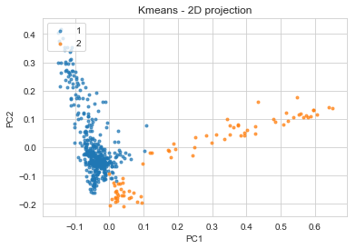

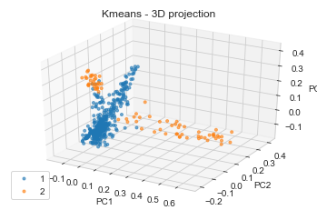

```python
plt2, plt3 = PCA_plots(X_3d=X_pca, labels=labels)
plt2.show()
plt3.show()
```

We can distinguish two or three well separated clusters, however it is important to validate our results with the original labeling of the dataset. So we repeat the process by labeling articles according to their tru labels:

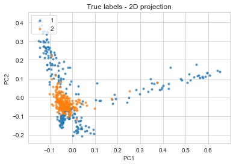

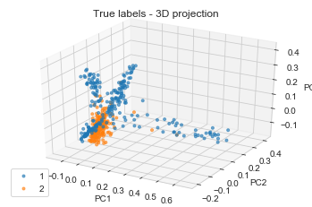

```python
plt, plt1 = PCA_plots(X_3d=X_pca, labels=y, title='True labels')
plt.show()
plt1.show()
```

K-means classifier our articles in a significantly different manner compared to the labels provided in our dataset. We validate this result by computing the accuracy between the Kmeans derived labels and true labels.

```python
print("Accuracy score: ", accuracy_score(labels,y))
```

```
Accuracy score:  0.35
```

It becomes obvious that the two classes have many characteristics in terms of the vocabulary that is used and that is why Kmeans fails to separate them properly. More specifically, it seems that the language used by articles that belong to class 2 is a subset of that used by class 1. Therefore, we expect a larger variety of concepts and news pertaining to class 1 compared to class 2 which is expected to contain articles around limited concepts. Despite the low variance of the principal components these results are totally in agreement with those of the Latent Dirichlet allocation where we saw that class 2 was focused in greek poltics while class 1 contained random, "shocking" and low quality news from all over the world.

We dive into further investigation of the 2 classes by repeating the above steps for both of them.

### K-means - class 1

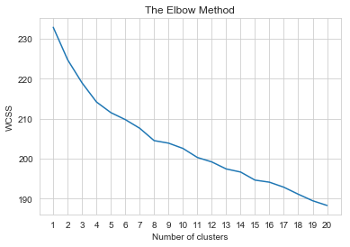

```python
plt = elbow_method_kmeans(X=corpus_tf_idf[y==0], clusters=20, save=False)
plt.show()
```

Based on the elbow method and seeking an appropriate point on the inertia curve we can conclude that 4 clusters is a balanced choice.

We proceed with the respective clustering and visualisations

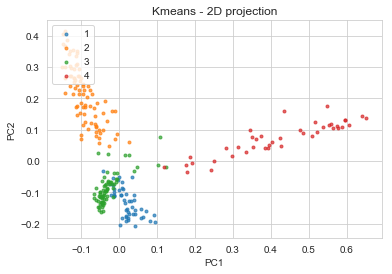

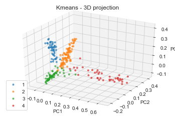

```python
n_topics = 4
kmeans = KMeans(n_clusters=n_topics).fit(corpus_tf_idf[y==0])
labels0 = kmeans.predict(corpus_tf_idf[y==0])
plt2, plt3 = PCA_plots(X_3d=X_pca[y==0], labels=labels0)
plt2.show()
plt3.show()
```

K-means seems to work very well in this case as well despite the small variances, in terms of separation of the topics of class 1.

The same does not happen for class 2

### Kmeans - class 2

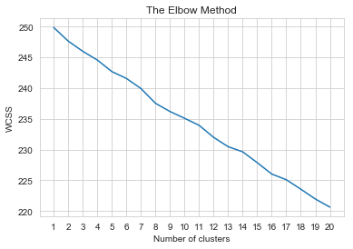

```python
plt = elbow_method_kmeans(X=corpus_tf_idf[y==1], clusters=20, save=False)
plt.show()
```

The elbow method offers no information for the appropriate number of clusters and data seems to be inseparable for any chosen number of clusters.

```
(<module 'matplotlib.pyplot' from 'C:\\ProgramData\\Anaconda3\\lib\\site-packages\\matplotlib\\pyplot.py'>,
 <module 'matplotlib.pyplot' from 'C:\\ProgramData\\Anaconda3\\lib\\site-packages\\matplotlib\\pyplot.py'>)
```

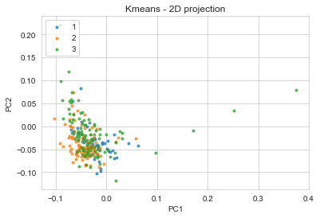

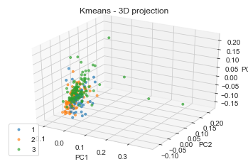

```python
n_topics = 3
kmeans = KMeans(n_clusters=n_topics).fit(corpus_tf_idf[y==1])
labels1 = kmeans.predict(corpus_tf_idf[y==1])
PCA_plots(X_3d=X_pca[y==1], labels=labels1)
```

### Kmeans as topic extractor and comparison with LDA

```python
corpus_tf_idf[y==0].shape
```

```
(243, 2036)
```

```python
labels0.shape
```

```
(243,)
```

```python
labs=[]
labs.append(labels0)
labs.append(labels1)
for label in [0,1]:
    print("Class", label+1, "\n")
    #split class 1 articles by cluster number
    words = np.array(vectorizer_no_stem.get_feature_names())
    tf_idf = pd.DataFrame(data=corpus_tf_idf[y==label].toarray(), columns=words)
    gb = tf_idf.groupby(labs[label])
    groups=[gb.get_group(x) for x in gb.groups]

    # display top 10 words of each cluster based on tf-idf and K-means clustering
    n = 10
    for i in range(len(groups)):
        tfidf_sorting = np.argsort(groups[i].values).flatten()[::-1]
        print("Top {} words of cluster #{}:\n{}\n".format(n, i+1, words[tfidf_sorting][:n]))
    print("=============================")
```

```
Class 1
```

[output not shown]

Conclusions:

- All methods fail to seperate the interclass topics (mainly because classes are not exactly separated based on topic but by source)
- During our research the three methods seemed to reach similar and consistent results in terms of class 1 as described in the previous section. (Shocking articles of drugs & war, top models etc. - Articles stemming mainly from click baiting news pages (e.g Newsbeast.gr))
- However due to the fuzziness of class 2, different runs led to slightly different topics for class 2. (Internal & External politics of Greece, Breaking news, Sports Contracts - articles that come from serious news agencies of Greece (ΑΠΕ-ΜΠΕ))
- The Kmeans algorithm seems to be more robust and seems to well separate terms inside intra class clusters.
- In contrast to LDA, the k-means algorithm "hard" assigns our articles to their respective cluster while LDA assigns them to topics in a probabilistic way.

## Community Detection | Louvain Method

I will extract communities of words that the inter-connected weighted edges are much more dense that the cross-connected edges. This quantity is being called **Modularity** and the algorithm that maximizes it is called **Louvain Method**. This method runs in O(n^2) when n is the number of nodes.

In order to result in a small number of communities (topics), I had to prune the weak edges of the network and keep the size of the communities small in order them to pe interpretable. The first parameter is called **support threshold**, while the second **resolution**.

The rest of the analysis consist of 3 parts. In the first one I examined how the quantity we want to maximize relates to the support threshold and the resolution. After this parameter tuning, I run the Louvain Method and extracted the communities. Finally, I present the results.

#### b.2.1) Parameter Tuning

find the pairs count and store them in a **NetworkX** way

```python
pairs_count= {}
label= 0
for doc in corpus[y==label]:
    #get all the tokens
    words= my_tokenizer(my_preprocessor(doc))

    #at least 2 tokens are needed to form a pair
    if len(words)<2:
        continue;

    #generate and count all possible pairs
    for i in range(len(words)):
        for j in range(i+1,len(words)):
            word1, word2= words[i], words[j]
            if word1 == word2 or word1==' ' or word2==' ':
                continue
            pair= tuple(sorted([word1,word2]))
            pairs_count[pair]= pairs_count.get(pair,0) + 1


#store them
limit= 10 #remove the pairs (edges) having count less than 10

with open(pickles_path+'word_network_class_{}.weighted.edgelist'.format(label), 'w', encoding="utf-8") as f:
    for pair,count in pairs_count.items():
        if count > limit:
            f.write('{} {} {}\n'.format(pair[0],pair[1],count))
```

examine how Modularity relates to resolution and support threshold

```python
def modularity_over_support(graph_file,res=1.0):

    def calculate_modularity():
        modularityList= []
        range_limit= range(10,100)
        nodes_num= []
        for limit in range_limit:
            ebig=[(u,v,d) for (u,v,d) in G.edges(data=True) if d['weight'] >= limit]
            G2=nx.Graph()
            G2.add_edges_from(ebig)
            nodes_num.append(len(G2.nodes()))
            comp= nx.connected_component_subgraphs(G2)
            big_cb= [ (cg,len(cg)) for cg in comp if len(cg)>=4]
            big_cb= sorted(big_cb, key= lambda t: t[1], reverse=True)
            partition = community.best_partition(big_cb[0][0],resolution=res)
            modularityList+= [community.modularity(partition,big_cb[0][0])]

        return range_limit, modularityList, nodes_num


    G= nx.read_weighted_edgelist(pickles_path+graph_file)
    range_limit, modularityList, nodes_num = calculate_modularity()
    return list(range_limit), modularityList, nodes_num
```

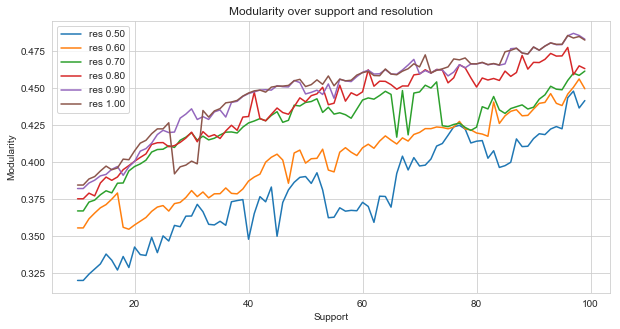

```python
#'word_network_class_0.weighted.edgelist'
#'word_network_class_1.weighted.edgelist'
graph_file= 'word_network_class_0.weighted.edgelist'
allModularityList=[]
resolutionList= [0.5,0.6,0.7,0.8,0.9,1]
for res in resolutionList:
    supportRange, modularityList, nodes_num= modularity_over_support(graph_file,res)
    allModularityList.append(modularityList)

plt.figure(figsize=(10,5))
plt.plot(supportRange,np.array(allModularityList).T)
plt.xlabel('Support')
plt.ylabel('Modularity')
plt.title('Modularity over support and resolution')
plt.legend([ 'res {:.2f}'.format(res) for res in resolutionList])
plt.savefig(images_path+'modulatiry_over_support'+str(resolutionList)[1:-1]+'_class0.jpg')
```

plot the (unpruned) network size over the support threshold

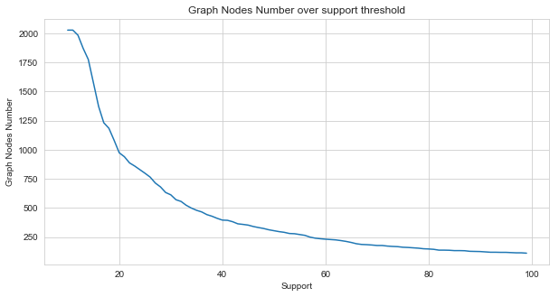

```python
plt.figure(figsize=(10,5))
plt.plot(supportRange,nodes_num)
plt.xlabel('Support')
plt.ylabel('Graph Nodes Number')
plt.title('Graph Nodes Number over support threshold');
```

#### b.2.2) Run the Louvain Method and present the results

```python
def preprocessing(graph_file, connCompSizeLimit,suppor_limit):
    #read the graph and prune weak edges
    G= nx.read_weighted_edgelist(pickles_path+graph_file)
    print(nx.info(G))
    print('\n_________________________\n\n')

    G= removeSmallEdges(suppor_limit, G)
    print('.... after pruning ....\n')
    print(nx.info(G))

    #keep the main connected component
    print('\n_________________________\n\n')
    print(nx.number_connected_components(G),' connected components')
    comp= nx.connected_component_subgraphs(G)
    big_cb= [ (cg,len(cg)) for cg in comp if len(cg)>=connCompSizeLimit]
    big_cb= sorted(big_cb, key= lambda t: t[1], reverse=True)
    print('\n',len(big_cb),' connected components with size >=',connCompSizeLimit)
    print(big_cb)

    return G, big_cb


def removeSmallEdges(weight,G):
    ebig=[(u,v) for (u,v,d) in G.edges(data=True) if d['weight'] >= weight]
    return G.edge_subgraph(ebig)


def drawGraph(subG):
    plt.figure(figsize=(20,10))
    pos = nx.spring_layout(subG)
    nx.draw_networkx_nodes(subG, pos, node_size = 10)
    nx.draw_networkx_labels(subG, pos, font_size= 15)
    nx.draw_networkx_edges(subG, pos)
    plt.show()


def createGephiFiles(G):
    #edges
    source= []
    target= []
    weights= []
    for edge in G.edges():
        source.append(int(edge[0]))
        target.append(int(edge[1]))
        weights.append(int(comG[edge[0]][edge[1]]['weight']))
    Type= ['Undirected']*len(source)

    gephiEdges= pd.DataFrame(data= list(map(list, zip(*[source,target,weights,Type]))), columns=['Source','Target','Weight','Type'])
    gephiEdges.to_csv('communities/gephi/input/gephi_edges.csv', index=False)


    #vertices
    Id= list(map(lambda x:int(x),G.nodes()))
    Label= [data[node] for node in G.nodes()]
    gephiNodes= pd.DataFrame(data=list(map(list, zip(*[Id,Label]))), columns=['Id','Label'])
    gephiNodes.to_csv('communities/gephi/input/gephi_nodes.csv', index=False)
```

```python
def community_detection(G,big_cb,res=1.0):

    def apriori(node):
        return sum([ edge[1]['weight'] for edge in G.adj[node].items()])

    def both(v1,v2):
        return G[v1][v2]['weight']

    def confidence(v1,v2):
        return both(v1,v2)/apriori(v1)

    def comb_confidence(v1,v2):
        return min(confidence(v1,v2),confidence(v2,v1))

    def best_partition():
        partition = community.best_partition(G,resolution=res)
        print('\n_________________________\n\n')
        print(max(set(partition.values()))+1,' communities found')
        print('modularity is: ',community.modularity(partition,G))

        return partition


    def orginizeNodersPerCommunities(partition):
        communities= {}
        for num in set(partition.values()):
            communities[num]= []

        for node,com in partition.items():
            communities[com]= [node]+communities[com]

        lengthLouvainCom= len(communities)
        for num in range(lengthLouvainCom, lengthLouvainCom+len(rest_cb)):
            communities[num]= rest_cb[num-lengthLouvainCom][0].nodes()

        return communities


    def rankCommunities(communities):
        utilities= {}
        for com,nodeList in communities.items():
            utility = 0
            for pair in itertools.combinations(nodeList, 2): #once each pair!
                if pair[0] in G[pair[1]]:
                    utility+= comb_confidence(pair[0],pair[1])
            com_len= len(nodeList)
            utilities[com]= utility/(com_len+1)#(2*(len(nodeList)+1))

        return utilities


    def sortRankedCommunities(utilities, communities):
        sortedCommunities = [(k, utilities[k],len(communities[k])) for k in sorted(utilities, key=utilities.get, reverse=True)]
        print('\n_________________________\n\n')
        for communityInfo in sortedCommunities:
            print('community ',communityInfo[0],' has utility ',communityInfo[1],' and consist of ',communityInfo[2],' nodes')

        return sortedCommunities

    def findCommunities():
        partition= best_partition()
        communities= orginizeNodersPerCommunities(partition)
        utilities= rankCommunities(communities)
        sortedCommunities= sortRankedCommunities(utilities, communities)
        return communities, sortedCommunities

    main_cb= big_cb[0][0]
    rest_cb= big_cb[1:]
    communities, communitiesInfo= findCommunities()
    return communities, communitiesInfo
```

### Class 1 analysis

```python
graph_file= 'word_network_class_0.weighted.edgelist'
res= 0.6
support_threshold= 80

#pre-process the grapgh
G, big_cb= preprocessing(graph_file, 4, support_threshold) #second parameter: minimum size of connected components to keep

#find communities
communities1, communitiesInfo= community_detection(G,big_cb,res)
```

```
Name:
Type: Graph
Number of nodes: 2027
Number of edges: 22441
Average degree:  22.1421

_________________________


.... after pruning ....

Name:
Type: Graph
Number of nodes: 148
Number of edges: 467
Average degree:   6.3108

_________________________


1  connected components

 1  connected components with size >= 4
[(<networkx.classes.graph.Graph object at 0x000000A2CDD23A58>, 148)]

_________________________


7  communities found
modularity is:  0.4211907977535221

_________________________


community  5  has utility  0.15886092595266899  and consist of  8  nodes
community  6  has utility  0.11400285071185219  and consist of  18  nodes
community  0  has utility  0.10229435831941805  and consist of  14  nodes
community  1  has utility  0.08519869835806354  and consist of  21  nodes
community  2  has utility  0.07032591534930706  and consist of  17  nodes
community  4  has utility  0.06643818262372808  and consist of  35  nodes
community  3  has utility  0.04761827207622017  and consist of  35  nodes
```

choose a community

```python
chosenCom= 5
```

print the words that form the chosen community

```python
for word in communities1[chosenCom]:
    print(word)
```

```
επιβατ
τελωνει
προεβ
παρανομ
κατασχες
ελεγχ
αυτοκινητ
εντοπις
```

The communities are being presented in descending order of importance (best-first).

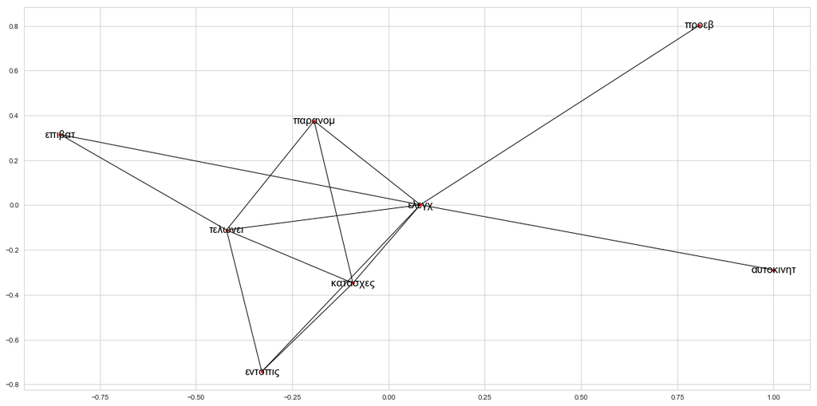

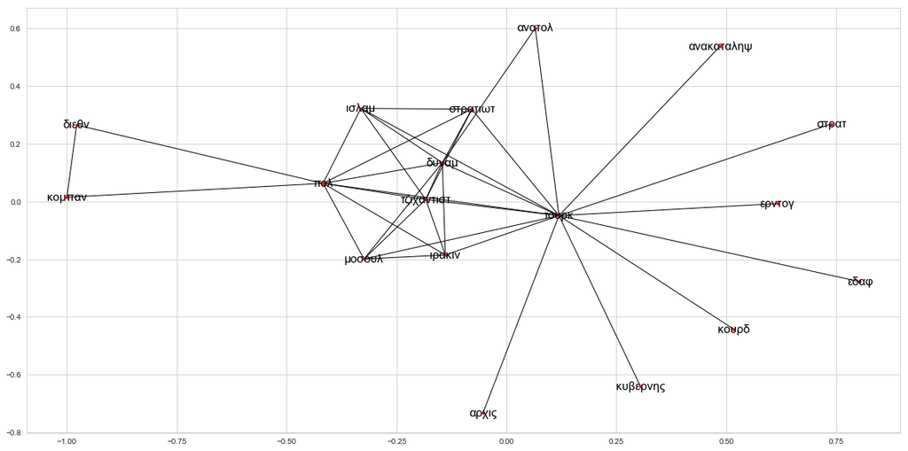

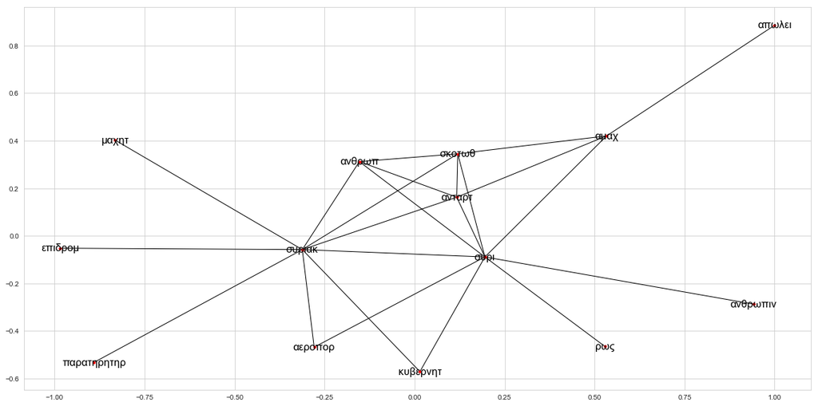

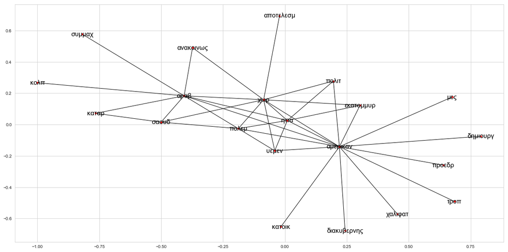

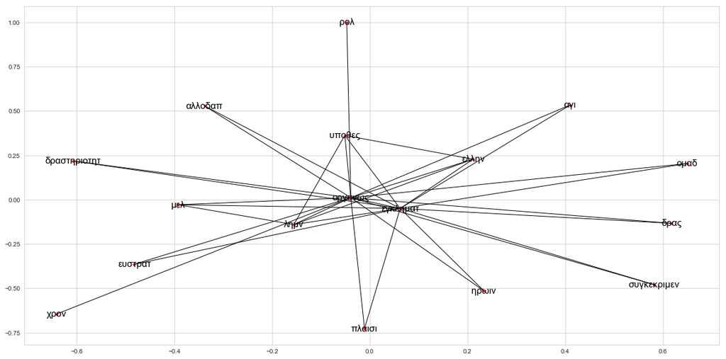

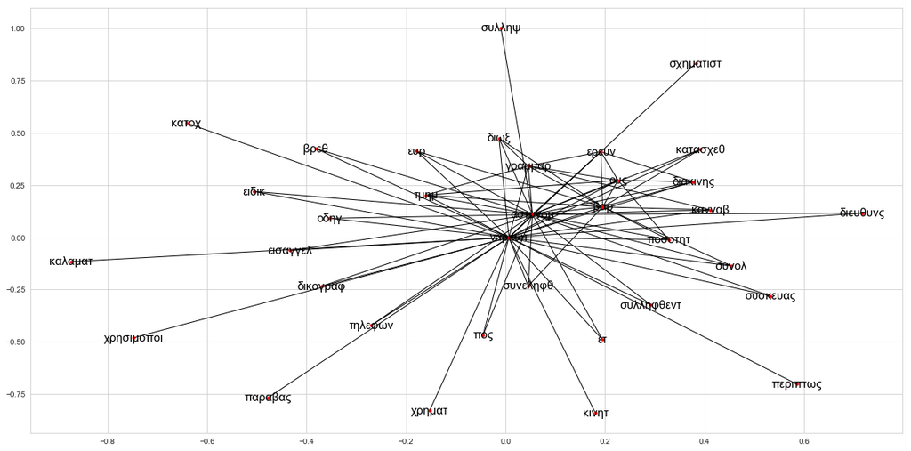

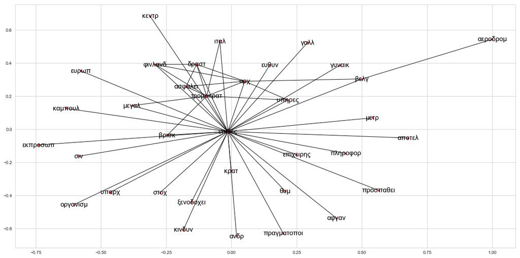

```python
for chosenCom, _,_ in communitiesInfo:
    comG= G.subgraph(communities1[chosenCom])
    drawGraph(comG)
```